# Cavalcante, lá onde a estrada termina

Black bird

07/01/2014

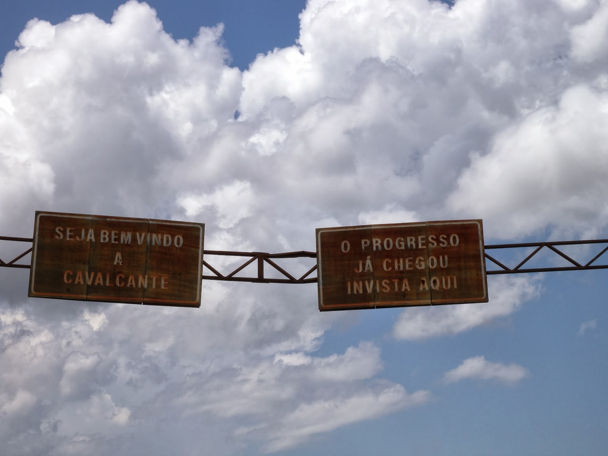

Y entonces manejas y manejas por una carretera recta interminable donde cada curva tiene un letrero de “peligrosa” por el simple hecho de ser curva hasta que derrepente llegas a Cavalcante un pueblito carretero al final de la culebra de asfalto, ahí mero donde el viento da la vuelta. A tan solo una hora y media de Alto Paraiso, el pueblito vive misteriosamente. El turismo no llega y cuando llega se va el mismo día debido a la mala comunicación/relación con las otras dos grandes ciudades de la Chapada, así los habitantes de Cavalcante viven de posaditas, restaurantes, ganadería y agricultura (tal vez) y demás, una ciudad muy simple con personas maravillosas que te hacen sentir en casa y visuales increíbles que te hacen sentir en el paraíso.

Cuenta con tres accesos (caminos) la carretera principal que entra por el este de la ciudad, viene de Alto Paraiso, la única asfaltada y que termina en la plaza del pueblo, ahí mero donde el viento da la vuelta. Después, tenemos dos de tierra, al sur la carretera hacia las cascadas de “Veredas, vale da lúa, etc!” y al norte la otra de tierra que va a Engenio II y otras comunidades Kalunga. Vale la pena ir al CAT (Centro de Atención al Turista) donde Joel un man de casi dos metros activista de Greenpeace te ayudará a producir tu viaje y te dará, como primera introducción, una lección de políticas públicas y sociología brasileña.

Conforme voy escribiendo me voy dando cuenta de los estructurado y aburrido que van a ser estas entradas, por lo menos las de las ciudades pues creemos que tener esto será súper útil para el futuro ya que no existe mucha infraestructura turística en este lugar y tener este tipo de referencias ayuda mucho, tal vez cuando hable de las cascadas logre viajarme en letras como me gusta, pero por lo mientras…

Ojo, Los nombres marcados con un (*) son bautizos nuestros, por lo que ir a Cavalcante y buscarlos por el nombre no es una buena idea.

## Hospedaje

Ya lo dije y lo repito, Cavalcante no es una ciudad turística, no se esperen súper hoteles, o posadas maravillosas, esperen espacios cómodos, útiles con lo mínimo necesario, aun que como siempre existen excepciones…

- *Posada da María (do sol)*, el famoso “BBB” Bueno, Bonito y Barato, es más, tengo fuertes presentimientos que el creador del término lo hizo al haberse hospedado ahí. Un digno hotel de película de terror gringa de carretera, cuenta con 13 habitaciones de 4x4 baño propio, dos camas individuales un ventilador, un tendedero afuera, estacionamiento, agua caliente y párale de contar. La dueña, María, una mujer muy atractiva y simpática vive atrás por lo que hasta wi-fii puedes lograr conseguir.
- *Posada Araras*, al parecer es la mejor posada del pueblo, yo no la visité (por obvias razones de exceso de presupuesto) pero me fue dicho que tiene desayuno, cuartos amplios, un espacio muy bonito con vista a las montañas además de una cascadas en el mismo espacio de la posada, también es la más cara.
- *Campamento*, siempre es una opción acampar. Es barato, algunos consideran romántico y demás. Saliendo por la carretera… “de arriba a la izquierda” dirección “Veredas” a 1 km del lado derecho de la terracería hay una muy buena zona de camping, cuentan con cocina, baños limpios y un buen espacio de pasto, les vuelvo a recordar que aquí llueve mucho por lo que les recomiendo llevar una tienda de campaña confiable.

## Alimentación

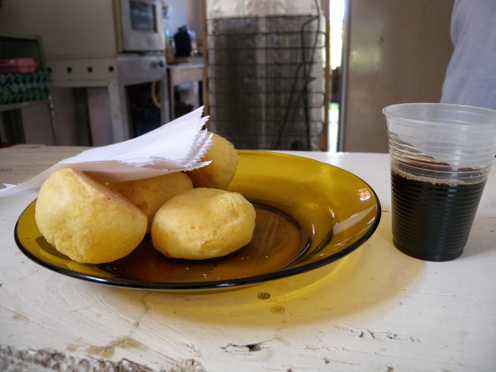

Para desayunar no se esperen el gran desayuno de la vida con fruta fresca, jugo, huevos recién hechos, cereal, hot cakes, ni nada de eso. Lo que van encontrar es “pão de queijo” un pan tradicional brasileiro buenísimo, café (ya hecho con mucho azúcar) y si tienen suerte un sandwich de jamón y queso. El mejor lugar para desayunar es con “Noacy do pão de queijo”, lo único que comerán será pão de quiejo en dos modalidades (sin queso dentro o con) y café o más bien azúcar con café, pero el dueño (en la foto) es un personaje.

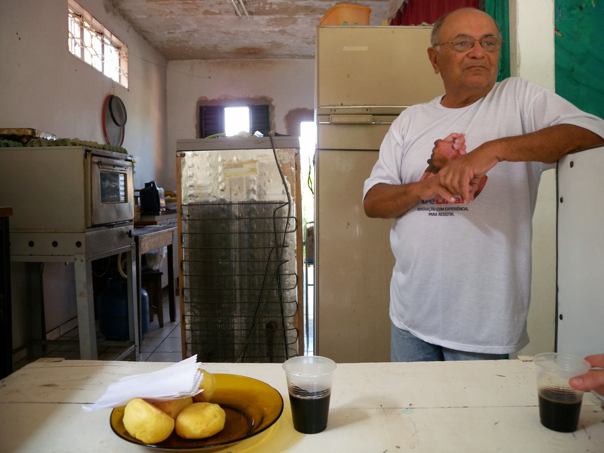

Nuestro amigo Noacy ( o Necy, Neicy.. ash no se), un personaje altamente político, ya trabajó para embajadas, tuvo su ganado y un lindo sitio en Cavalcante. Cuenta historias de su vida, sus asañas pasadas y situaciones amorosas mientras desayunas en su precaria cafetería. Un hombre con gran corazón y capacidad es un ejemplo de persona y es la primera vez (de varias) que mi fe en la humanidad regresó. Sin duda una de las personalidades más queridas de este viaje, espero volver a verlo con su casa lista y su cafetería bien arregladita, ¡no se lo pierdan y mándenle saludos de mi parte!

¡Casi lo olvido! Obviamente nadie usa los nombres de las calles de Cavalcante así que la instrucción para llegar a la cafetería es: “enfrente a la cancha de basquet que está atrás de la terminal de autobuses hay una cafetería en donde hay un refrigerador viejo afuera, ahí está el lugar. Se llama”Lanchonete deliciosa“.

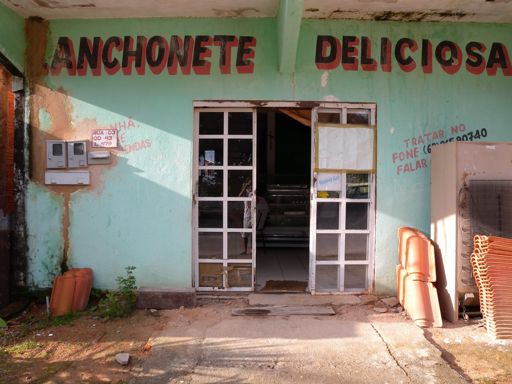

- *Pimenta’s Lanches* es una cafetería en la “calle del puente” paralela a la principal, sirve sandwiches, jugos (algunos) café y pan de desayuno, es bueno y hace paro para las caminatas, la dueña “Jo” te puede preparar café sin azúcar si le pides. Es muy barata pero recuerda que si no hay luz no habrá casi nada ya que todos sus utensilios son eléctricos. La clave está que, afuera del lugar hay un árbol de mangos, ahí puedes tomar un par para la caminata que vayas a hacer, una joya.

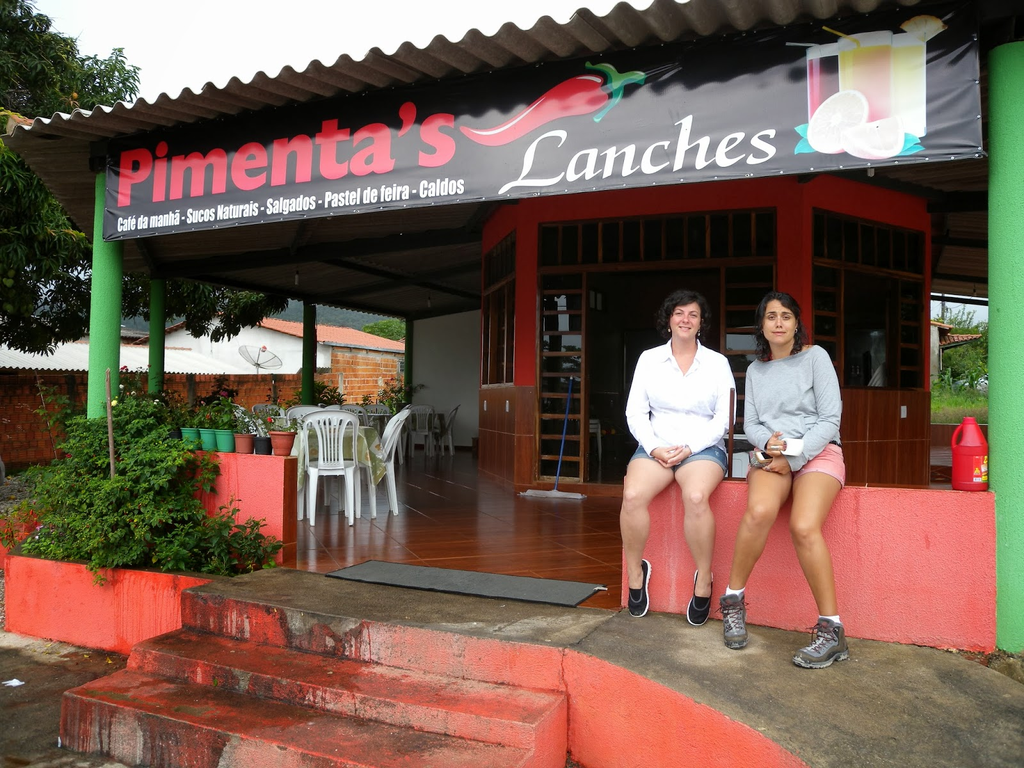

Para comer la cosa se complica, si bien hay muchos lugares de pizza (no sé por qué) comer lo que a muchos nos gusta, la “comida tradicional” es difícil de encontrar, pero afortunadamente no imposible. En la misma calle que el “Pimenta’s Lanches” hay un restaurante, es en la próxima esquina, el bar da Rosa* sirve comida a montones y buenísima, ya sabes que va ser deliciosa cuando la dueña recolecta de una maceta al lado de tu mesa, comino y otras hiervas para tu plato, ¡el verdadero sabor casero caray!

Todos estos lugares son reales sin embargo los nombres no todos coinciden con la realidad pues uno tiende a rebautizar las cosas. Si alguien alguna vez usa este espacio como guía, pregunten por las personas, recuerden que es un pueblo de no más de 600 habitantes, todos se conocen y los nombres si son verdaderos.

Creo que con esto finalizo Cavalcante ciudad, me gustaría hacer una reflexión personal con lo que viví ahí, las personas de esta ciudad son completamente abiertas a personas de afuera. Uno siente que llegó a un lugar familiar, todos te tratan bien, te ayudan te comparten experiencias, historias que cualquier clasificaría como más que personales, no tienes como sentirte solo o perdido. Se siente un aire amable, de amistad, felicidad y gusto por la vida, pero también de lucha y conciencia de cambio, no logré identificar el tipo de pobreza triste que se vive en las grandes ciudades, aquí todos sonreían, los que tienen poco luchaban día a día y los que tienen un poco más se mostraban preocupados por sacar la ciudad adelante. Claro que vi poco, tan solo 3 días y así, pero es la impresión que me dio. Es sin duda alguna una gran ciudad con una enorme población que te encanta en escasos 3 días.

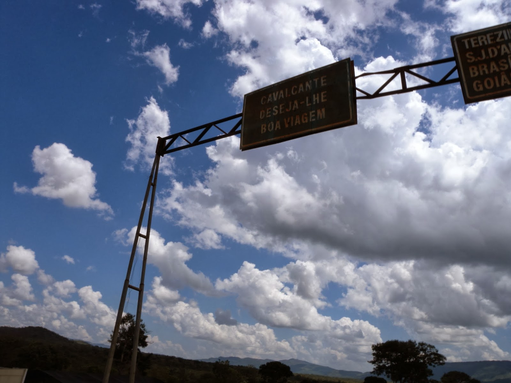